# Ivan Hanigan - Disentangle Things

**Disentangle Things by Ivan Hanigan**

- Notes
- About Open Notebooks
- Projects
- CV
- [Search this Site](http://lmgtfy.com/?q=site%3Aivanhanigan.github.io)

## Welcome to my Open Notebook

This is an Open Notebook with [Selected Content - Delayed](https://en.wikipedia.org/wiki/Open_notebook_science). All content is licenced with CC-BY. Find out more Here.

[figure not shown]

# using-additional-header-rows-for-metadata

# Comment on eMast recommendations

ivan.hanigan@anu.edu.au

### Introduction

- I was lucky to be forwarded a copy of the document “DRAFT Best practices for collecting, processing and collating plant trait data” (V0.0).
- What I like most about this is the statement on page nine under “3. Best practice collection techniques” that “Datasets should be maintained following two simple practices of formatting and cataloguing”.
- I think the recomendations are very sensible but I have the following comment regarding the proposed file structure shown in the table

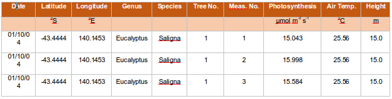

- I have not used the second row for the units before, but rather have encoded this information in a second metadata file that I keep with the main data file.
- This second row does seem attractive
- BUT as this might be interpreted as the first row of data after the header row of column names this needs extra code to be written to allow importation to statistics packages.
- While this can be easily handled by writing extra code to treat this first row separately, this does seem a bit risky to expect ordinary data users to do so.
- I wonder if the intention of the authors is to include this in the column NAME rather than just in the column as the statement currently reads (“the units of measurement and an expanded definition of the data recorded in each column”) and the table shows?
- For example the R code given in the Appendix “R script to aggregate unprocessed trait data into summary statistics ready for the EMP DATABASE”

### R code

- The eMast Document provides an interesting appendix with R codes.
- The following is an attempt to make a vignette that will run with the example data provided.

#### Construct some fake data

```r
dat <- read.csv(textConnection("Date    ,Latitude,Longitude,Genus,Species,Tree No.,Meas. No.,Photosynthesis,Air Temp.,Height\n         ,      oS,       oE,          ,       ,   , ,umol m-2 s-1, oC, m\n1/10/2004,-43.4444,140.1453 ,Eucalyptus,Saligna,  1,1,15.043,25.56,15\n1/10/2004,-43.4444,140.1453 ,Eucalyptus,Saligna,  1,2,15.998,25.56,15\n1/10/2004,-43.4444,140.1453 ,Eucalyptus,Saligna,  1,3,15.584,25.56,15\n"))
# write a couple of fake data files
for (i in 1:2) {
    write.csv(dat, paste("Book", i, ".csv", sep = ""), row.names = F)
}
# show me the data
print(xtable(dat), type = "html")
```

|  | Date | Latitude | Longitude | Genus | Species | Tree.No. | Meas..No. | Photosynthesis | Air.Temp. | Height |
| --- | --- | --- | --- | --- | --- | --- | --- | --- | --- | --- |
| 1 |  | oS | oE |  |  |  |  | umol m-2 s-1 | oC | m |
| 2 | 1/10/2004 | -43.4444 | 140.1453 | Eucalyptus | Saligna | 1 | 1 | 15.043 | 25.56 | 15 |
| 3 | 1/10/2004 | -43.4444 | 140.1453 | Eucalyptus | Saligna | 1 | 2 | 15.998 | 25.56 | 15 |
| 4 | 1/10/2004 | -43.4444 | 140.1453 | Eucalyptus | Saligna | 1 | 3 | 15.584 | 25.56 | 15 |

#### Run the aggregation of trait data program provided in eMast doc

```r
library(stringr)
# This function summarises the data, one just needs to past the parameter of
# interest and the quantities by which it varies around.
do.sumy <- function(pars, lab, dat) {
    epars <- as.formula(pars)
    mu <- aggregate(epars, data = dat, mean)
    md <- aggregate(epars, data = dat, median)
    se <- aggregate(epars, data = dat, sd)
    mx <- aggregate(epars, data = dat, min)
    mn <- aggregate(epars, data = dat, max)
    NN <- aggregate(epars, data = dat, length)
    drp0 <- unlist(strsplit(pars, "\\+"))
    drp <- -length(drp0):-1
    df1 <- cbind(mu, md[, drp], se[, drp], mx[, drp], mn[, drp], NN[, drp])
    df2 <- cbind(df1, Parameter = lab)
    hd1 <- gsub("^\\w.*.~", "", drp0)
    names(df2) <- c(hd1, "Mean", "Median", "Std", "Min", "Max", "N", "Parameter")
    return(df2)
}

# Not Required setwd('~/where/is/the/data/?')
files <- list.files(pattern = "*.csv")
# files
data <- lapply(files, read.csv, header = T, stringsAsFactors = F, strip.white = T)
```

#### Minor modifications to make it work

- I needed to write the following to read the csv with metadata row

```r
#### Notes str(data) as expected, these are sometimes imported as character due
#### to the second row so need to fix it also because the data object is a list
#### of data.frames, it is easier to run the example if we will just create
#### individual data frames
read_metadata_csv <- function(filename) {
    dat <- read.csv(filename, skip = 1)
    col.defs <- names(read.csv(filename, nrow = 0))
    unit.defs <- read.csv(filename, nrow = 1, stringsAsFactors = F)
    attributes(dat)$unit.defs <- unit.defs[1, ]
    names(dat) <- col.defs
    return(dat)
}
# files
data <- read_metadata_csv(files[1])
# str(data)
```

#### Now finish off with the example code

```r
#### NOTE this is not relevant here so commented out If the Genus and Species
#### is not separate, then split it up split.spp <- strsplit( data$Spp.Name, '
#### ' ) data$Genus <- sapply( split.spp, '[[', 1 ) data$Species <- sapply(
#### split.spp, '[[', 2 )



# Get the summary stats for each interesting trait
Height <- do.sumy("Height~Photosynthesis+Genus+Species", "Height", data)
# show me the data
print(xtable(Height), type = "html")
```

|  | Photosynthesis | Genus | Species | Mean | Median | Std | Min | Max | N | Parameter |
| --- | --- | --- | --- | --- | --- | --- | --- | --- | --- | --- |
| 1 | 15.04 | Eucalyptus | Saligna | 15.00 | 15 |  | 15 | 15 | 1 | Height |
| 2 | 15.58 | Eucalyptus | Saligna | 15.00 | 15 |  | 15 | 15 | 1 | Height |
| 3 | 16.00 | Eucalyptus | Saligna | 15.00 | 15 |  | 15 | 15 | 1 | Height |

```r
#### not available Vcmax <- do.sumy( 'Vcmax25~CO2.treatment+Genus+Species',
#### 'VCMAXM25', data ) Jmax <- do.sumy( 'Jmax25~CO2.treatment+Genus+Species',
#### 'JMAXM25', data ) VjVn <- do.sumy( 'J.V~CO2.treatment+Genus+Species',
#### 'VJVN', data ) Tleaf <- do.sumy(
#### 'Tleaf_avg~CO2.treatment+Genus+Species','TLEAF', data ) all.Y <- rbind(
#### Vcmax, Jmax, VjVn, Tleaf )

## # Re-arrange the columns to the correct order exp.dat1 <- subset( all.Y,
## select=c('Genus','Species','Parameter','Mean','Median','Std','Min','Max','N','CO2.treatment')
## )

## # save it somewhere write.table( exp.dat1, 'choose/folder/to/save/to.csv',
## sep=',', row.names=F, col.names=T, na='' )
```

Posted in Data Documentation

17 May 2014

# reproducible-research-reports-using-emacs-orgmode-export-to-knitr

- Emacs orgmode is so good for Reproducible Research Reports. Check out the paper by Eric Schulte et al ["A Multi-Language Computing Environment for Literate Programming"](http://www.jstatsoft.org/v46/i03%E2%80%8E)
- it provides a good export function to convert the code file into a html or latex report using C-c C-e h OR C-c C-e l respectively.
- but I have found there are some limitations with these export reports compared to knitr
- primarily the limitation of the need to include the images as seperate files whereas knitr encodes these explicitly in the report is the one I dislike the most
- another limitation is the way that tables are handled
- HOWEVER the code editing features of Emacs orgmode are so superior to the other options I have tried to write knitr documents in that I feel it is worth trying to find some middle ground.
- I have been happy for a little while using a method of writing documents in Emacs orgmode and exporting the text and code Chunks to a knitr RMD file, and then compiling that file to create the report.
- I have set up an example using the classic Challenger Space Shuttle logistic regression [in this file](https://bitbucket.org/ivanhanigan/eda-template/raw/3f8d20253bf6a2389ed720033edf171ca74ca796/emacs2knitr.org)

# Reproducible Research Report using Emacs orgmode to knitr

ivan.hanigan@anu.edu.au

### Introduction

- This is an example or a Reproducible Research Report.
- The report is the output of a program written in Emacs orgmode, which constructs a knitr document and creates this HTML output.

### logistic regression of the challenger disaster

The problem was with the failure rate (and number of) O-rings that failed (n.fail) related to the temperature (temp).

#### name:create-data

```r
# n.fail = failed o rings
# totalMinusNfail = total-n.fail
# total = there were 6 o rings for each of 23 attempts
# pfail = probability of fail pFail <- n.fail/total
# temp = temperature (F)

dat <- read.csv(textConnection(
"nfail, totalMinusNfail, total,     pFail,       temp
2,               4,     6,          0.3333333,   53
0,               6,     6,          0.0000000,   66
0,               6,     6,          0.0000000,   68
1,               5,     6,          0.1666667,   70
0,               6,     6,          0.0000000,   75
0,               6,     6,          0.0000000,   78
1,               5,     6,          0.1666667,   57
0,               6,     6,          0.0000000,   67
0,               6,     6,          0.0000000,   69
1,               5,     6,          0.1666667,   70
2,               4,     6,          0.3333333,   75
0,               6,     6,          0.0000000,   79
1,               5,     6,          0.1666667,   58
0,               6,     6,          0.0000000,   67
0,               6,     6,          0.0000000,   70
0,               6,     6,          0.0000000,   72
0,               6,     6,          0.0000000,   76
0,               6,     6,          0.0000000,   81
1,               5,     6,          0.1666667,   63
0,               6,     6,          0.0000000,   67
0,               6,     6,          0.0000000,   70
0,               6,     6,          0.0000000,   73
0,               6,     6,          0.0000000,   76
"))
```

| nfail | totalMinusNfail | total | pFail | temp |
| --- | --- | --- | --- | --- |
| 2 | 4 | 6 | 0.33 | 53 |
| 0 | 6 | 6 | 0.00 | 66 |
| 0 | 6 | 6 | 0.00 | 68 |
| 1 | 5 | 6 | 0.17 | 70 |
| 0 | 6 | 6 | 0.00 | 75 |
| 0 | 6 | 6 | 0.00 | 78 |
| 1 | 5 | 6 | 0.17 | 57 |
| 0 | 6 | 6 | 0.00 | 67 |
| 0 | 6 | 6 | 0.00 | 69 |
| 1 | 5 | 6 | 0.17 | 70 |
| 2 | 4 | 6 | 0.33 | 75 |
| 0 | 6 | 6 | 0.00 | 79 |
| 1 | 5 | 6 | 0.17 | 58 |
| 0 | 6 | 6 | 0.00 | 67 |
| 0 | 6 | 6 | 0.00 | 70 |
| 0 | 6 | 6 | 0.00 | 72 |
| 0 | 6 | 6 | 0.00 | 76 |
| 0 | 6 | 6 | 0.00 | 81 |
| 1 | 5 | 6 | 0.17 | 63 |
| 0 | 6 | 6 | 0.00 | 67 |
| 0 | 6 | 6 | 0.00 | 70 |
| 0 | 6 | 6 | 0.00 | 73 |
| 0 | 6 | 6 | 0.00 | 76 |

```r
#### learnR-logistic
png("pfail.png")
with(dat, plot(temp, pFail, pch = 16, xlim = c(40, 100), ylim = c(0, 0.4)))
title("A plot of the proportion failed by temperature")
dev.off()
```

pdf 2

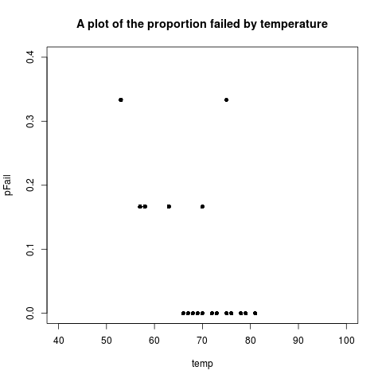

#### fit model

```r
# newnode: linear names(dat)
resp <- cbind(dat$nfail, dat$totalMinusNfail)
temp <- dat$temp
linear <- glm(resp ~ 1 + temp, family = binomial(link = logit))
# TODO this just prints the codes not the table?  xtable(linear, type =
# 'html')
```

### Model Diagnostics

```r
cf <- linearoutput$coeff
signif(cf[which(row.names(cf) == "temp"), "Estimate"], 2)
```

[1] -0.12

```r
png("challengerLogistic.png")
par(mfrow = c(2, 2))
plot(linear)
dev.off()
```

pdf 2

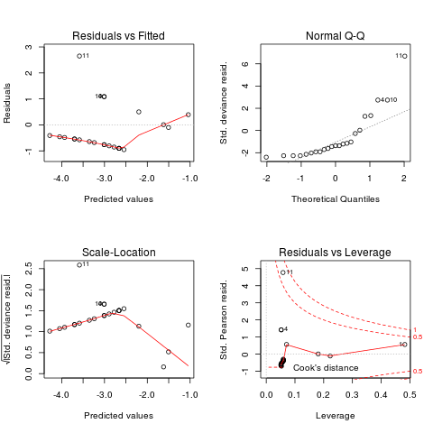

### plot-model

```r
dummy <- data.frame(temp = seq(20, 100, 1))
pred.prob <- predict.glm(linear, newdata = dummy, type = "resp")
png("pfailfit.png")
with(dat, plot(temp, pFail, xlab = "Launch Temperature (F)", ylab = "Proportion Failing",
    pch = 16, xlim = c(20, 100), ylim = c(0, 1)))
lines(dummy$temp, pred.prob)
dev.off()
```

pdf 2

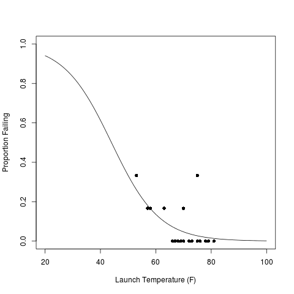

Posted in research methods

17 May 2014

# ms-access-to-postgresql-in-64-bit-windows

- In 2011 we published a paper on "Creating an integrated historical record of extreme particulate air pollution events in australian cities from 1994 to 2007".
- I used a PostGIS/PostgreSQL server to host the database and MS Access clients for data entry by my co-author's at their own institutions (thousands of kms away)
- This worked great but recently I realised that updating to windows 64 bit has broken the ODBC connection
- to fix it I followed the instructions [here](http://www.youlikeprogramming.com/2011/09/postgresql-and-odbc-in-64-bit-windows/)
- You need to install both the 32 and 64 bit executables
- Assuming you use the 32 bit windows office suite (recommended) then use the command below to open the ODBC connections tool and add a DSN for your postgres database

#### Code:

```
Go to Start -> Run (or Press Windows+R keys) and enter
%WINDIR%\SysWOW64\odbcad32.exe
```

- On either the User DSN (DSNs available for only that user) or System DSN (DSNs available to every user) tab, click the Add button. Scroll down the list and find the PostgreSQL ODBC Driver.
- You may select ANSI or UNICODE (For future support I personally prefer UNICODE), and click Finish.
- Data Source refers to the programmable name of the DSN Entry. Stick to lower-case letters and underscores. Ex: psql_server
- Specify the Database, Server, User Name and Password to your PostgreSQL server.
- Click the Test button to ensure everything has been specified correctly.
- Click the Save button to create the DSN.

Posted in research methods

10 May 2014

# cwt-lter-data-submission-template-critique

- I recently reviewed a tool for collecting metadata about Long Term Ecological Resarch (LTER) data
- it is just an Excel spreadsheet called cwt_data_subm_template_2013.xls
- You can download a copy here www.coweeta.uga.edu/resources/forms/cwt_data_subm_template_2013.xls
- LTER is The U.S. Long-Term Ecological Research (LTER) network
- I made the following notes, this is not intended to be a nasty critique
- The following is a few Frank and Fearless comments I'll be using to compare the pros and cons of a variety of data documentation approaches

#### Critique

- opened first on windows, saw comments on cells with instructions
- opened next on linux with libreOffice and comments are gone
- opened at the last tab (split in two for no reason?)
- noticed recommended name "GCE site" = Site, otherwise "permanent plot" = Plot?
- [GCE = Georgia Coastal Ecosystems LTER program](http://nsmn1.uh.edu/steve/research/gce/gce.htm)
- flip to first tab, point 4 suggests there is some export functionality I cannot see (a VBA script?)
- cell 11 a NOTE: When submitting updated metadata or re-using templates please highlight fields with modified contents in yellow
- and use glitter pen??? (See this great post [called excel-is-not-your-lab-notebook!](http://practicaldatamanagement.wordpress.com/2013/12/16/excel-is-not-your-lab-notebook/)
- personnell tab OK
- instrumentation, variable measured is free text. ok but for eg "max temp", "temperature maxima", "maximum temperature (c)" "maximum temperature in 24 hours after 9am local time in degrees" etc
- too wide, last column was off my wide screen! noticed wasted real estate in column A

#### Moving on to the tabular data sheet

- I don't like this "– Paste or enter your data values into the 'Values' section (white cells), starting with the indicated cell"
- this is an invitation for clerical error! Too many "copy-and-paste" actions will inevtably introduce errors

I do like the extra metadata Column Name:

- Description:
- Units:
- Data type:
- Variable type:
- Number type:
- Precision:
- Code values:
- Calculations:
- QC: Minimum Valid:
- QC: Minimum Expected:
- QC: Maximum Expected:
- QC: Maximum Valid:
- QC: Custom:

#### Other issues:

– Fill in missing values in the table with NaN (not a number), including text fields, and do not skip columns - but what about missing values imbued with other meanings (NA = not observed, censored etc)? - ask users to format digit rounding in Excel?? oh no - old excel users may still be restricted to 65,536 rows by 256 columns. - non tabular sheet is ok

Posted in Data Documentation

09 May 2014

# morpho-has-an-issue-with-zero-length-strings-as-missing-data

#### R Code:

```
datatext <- 'Treat, Before, After1, After2
a,,-9999,9999
a,,-9999,9999
a,,-9999,9999
a,,-9999,9999
a,,-9999,9999
a,,-9999,9999
a,,-9999,9999
a,,-9999,9999
0,  2.833213344,    1.609437912,    2.48490665
0,  1.791759469,    2.197224577,    2.079441542
0,  3.044522438,    2.708050201,    3.135494216
0,  2.772588722,    1.791759469,    2.197224577
0,  1.098612289,    1.609437912,    2.63905733
1,  2.944438979,    0.693147181,    1.791759469
1,  2.564949357,    0.693147181,    1.791759469
1,  2.564949357,    1.609437912,    1.609437912
1,  0.693147181,    1.098612289,    1.098612289
1,  1.609437912,    0,      1.098612289'
analyte <- read.csv(textConnection(datatext))
write.csv(analyte, "inst/extdata/morpho-bug-empty-na.csv", row.names = F, na= "", quote=F)
```

- Unfortunately for this blog entry, the example above doesn;t exhibit the problem!
- you can see what happens by selecting the "treat consecutive delimiters as as one" option
- showing that the data from the 3rd and 4th cols shifts to the right
- this is what happened to us but we were not able to modify this behaviour by changing that option!
- The problem only occurred when we had a file big file (200+ columns)
- the problem occured at col 23, shown in the image below

[figure not shown]

- this column is ftyp[12] which has 62 rows of missing and then some text codes.
- the next 24th column is aerial[10] and it is this one that is then read incorrectly by morpho. The importer makes the error of reading blanks for the first few rows and then *, even though in reality it is * and then date 1/06/2006 (shown in the image below)

[figure not shown]

- and finally col 25 fire[13] now appears as * and the date 1/06/2006 but it should be a different number of *s and the date 2/04/2007 further down

[figure not shown]

### Workaround

- to deal with this in this case we replaced all zero length strings as "NA"
- this is probably a good idea in most cases, except when NA is not an appropriate value and so in those cases we replaced with the word "blank"

### Conclusions

- This issue is probably rare and might be fixed in the newer version of Morpho
- We don;t use new morpho because we are still using the old metacat
- I thought it worth reporting here

Posted in Data Documentation

02 May 2014

« Previous Next »

Banner Artwork by Cindy Hales. Site powered by [Jekyll](https://github.com/mojombo/jekyll) with [Carrington](http://carringtontheme.com) theme.